# Day 1, Session 2: Data wrangling

Dusica Filipovic Durdevic

2026-09-14

## Scripting preserves future efforts

- Saving the code
  - Saving time
  - Data reproducibility

## Loading the data

- Opening data file from the working directory

```r
read.table("Data_practice.txt",sep="\t", header=TRUE)
```

```
##   Participant       Manipulation Recall  IQ DominantHand
## 1          s1      control_group      7 101  righthanded
## 2          s2 experimental_group     15 124   lefthanded
## 3          s3      control_group      5 110   lefthanded
## 4          s4 experimental_group     11  98  righthanded
## 5          s5      control_group     10 103  righthanded
## 6          s6      control_group      8  99  righthanded
## 7          s7 experimental_group     14 123   lefthanded
## 8          s8      control_group      6 109   lefthanded
## 9          s9 experimental_group     18 102  righthanded
```

- Loading the data / opening data file from the target directory using path

```r
read.table("c:/Eowyn/Dokumenti/Obuke/!MOJE_2026/Podaci_vezba.txt",sep="\t", header=TRUE)
```

```
##   Ispitanik          Manipulacija Reprodukcija  IQ   Rukost
## 1        s1       kontrolna grupa            7 101 desnoruk
## 2        s2 eksperimentalna grupa           15 124  levoruk
## 3        s3       kontrolna grupa            5 110  levoruk
## 4        s4 eksperimentalna grupa           11  98 desnoruk
## 5        s5       kontrolna grupa           10 103 desnoruk
## 6        s6       kontrolna grupa            8  99 desnoruk
## 7        s7 eksperimentalna grupa           14 123  levoruk
## 8        s8       kontrolna grupa            6 109  levoruk
## 9        s9 eksperimentalna grupa           18 102 desnoruk
```

- Working with large data files, we will assign them a name

```r
df <- read.table("Data_practice.txt",sep="\t", header=TRUE)
```

```r
df <- read.csv("Data_practice.csv")           # comma delimited (default)
```

```r
df <- read.delim("Data_practice.txt")         # tab delimited (default)
```

```r
# library(readxl)
# df <- read_excel("Data_practice.xlsx")
```

> Fun fact

> You will come up with a name for a data frame yourself, but a common practice is to name it df

> Caution

> Avoid reserved names (e.g. data)

## Data wrangling

## Data wrangling

- A set of procedures that we apply to a data frame before the analysis
  - Cleaning the data
    - Excluding participants, items
    - Filtering
  - Transforming variables
    - log-transforming, scaling
  - Reshaping the data frame
    - Wide-to-long format
    - Joining dataframes
  - Renaming
    - Variables
    - Category levels

## Let’s start

- Load the data

```r
df <- read.table("Data_practice.txt",sep="\t", header=TRUE)
```

- Inspect the number of rows and columns of the data frame

```r
dim(df)
```

```
## [1] 9 5
```

## Cleaning the data

## Load and inspect the data

- Have a quick look at the data frame

```r
head(df)
```

```
##   Participant       Manipulation Recall  IQ DominantHand
## 1          s1      control_group      7 101  righthanded
## 2          s2 experimental_group     15 124   lefthanded
## 3          s3      control_group      5 110   lefthanded
## 4          s4 experimental_group     11  98  righthanded
## 5          s5      control_group     10 103  righthanded
## 6          s6      control_group      8  99  righthanded
```

- Inspect the type of variables

```r
str(df)
```

```
## 'data.frame':    9 obs. of  5 variables:
##  $ Participant : chr  "s1" "s2" "s3" "s4" ...
##  $ Manipulation: chr  "control_group" "experimental_group" "control_group" "experimental_group" ...
##  $ Recall      : int  7 15 5 11 10 8 14 6 18
##  $ IQ          : int  101 124 110 98 103 99 123 109 102
##  $ DominantHand: chr  "righthanded" "lefthanded" "lefthanded" "righthanded" ...
```

## Conduct conversion to appropriate data type

- Base R

```r
df$Participant = as.factor(df$Participant)
df$Manipulation = as.factor(df$Manipulation)
df$DominantHand = as.factor(df$DominantHand )
df$Recall = as.numeric(df$Recall)
df$IQ = as.numeric(df$IQ)
```

- dplyr

```r
library(dplyr)

df = df %>%
  mutate(
    Participant  = as.factor(Participant),
    Manipulation = as.factor(Manipulation),
    DominantHand = as.factor(DominantHand),
    Recall       = as.numeric(Recall),
    IQ           = as.numeric(IQ)
  )
```

- Inspect the type of variables again

```r
str(df)
```

```
## 'data.frame':    9 obs. of  5 variables:
##  $ Participant : Factor w/ 9 levels "s1","s2","s3",..: 1 2 3 4 5 6 7 8 9
##  $ Manipulation: Factor w/ 2 levels "control_group",..: 1 2 1 2 1 1 2 1 2
##  $ Recall      : num  7 15 5 11 10 8 14 6 18
##  $ IQ          : num  101 124 110 98 103 99 123 109 102
##  $ DominantHand: Factor w/ 2 levels "lefthanded","righthanded": 2 1 1 2 2 2 1 1 2
```

## Duplicated rows

- Base R
  - Check if there are duplicated rows

```r
any(duplicated(df))
```

```
## [1] FALSE
```

- Count duplicated rows

```r
sum(duplicated(df))
```

```
## [1] 0
```

- Show duplicated rows

```r
df[duplicated(df), ]
```

```
## [1] Participant  Manipulation Recall       IQ           DominantHand
## <0 rows> (or 0-length row.names)
```

- Remove duplicated rows

```r
df = df[!duplicated(df), ]
```

- dplyr

```r
df %>%
  filter(duplicated(.))
```

```
## [1] Participant  Manipulation Recall       IQ           DominantHand
## <0 rows> (or 0-length row.names)
```

- Remove duplicated rows

```r
df %>%
  distinct()
```

```
##   Participant       Manipulation Recall  IQ DominantHand
## 1          s1      control_group      7 101  righthanded
## 2          s2 experimental_group     15 124   lefthanded
## 3          s3      control_group      5 110   lefthanded
## 4          s4 experimental_group     11  98  righthanded
## 5          s5      control_group     10 103  righthanded
## 6          s6      control_group      8  99  righthanded
## 7          s7 experimental_group     14 123   lefthanded
## 8          s8      control_group      6 109   lefthanded
## 9          s9 experimental_group     18 102  righthanded
```

## Missing values

- Base R
  - Check if there are any missing values

```r
# in total
sum(is.na(df))
```

```
## [1] 0
```

```r
# per column
colSums(is.na(df))
```

```
##  Participant Manipulation       Recall           IQ DominantHand
##            0            0            0            0            0
```

- Remove rows with missing values

```r
# remove rows with any missing value
df_clean = na.omit(df)
# remove rows with missing values in specific columns
df_clean = df[complete.cases(df[, c("IQ", "DominantHand")]), ]
```

- Replace missing values with group mean

```r
df$IQ[is.na(df$IQ)] = mean(df$IQ, na.rm = TRUE)
# na.rm = TRUE tells R to ignore missing values
#              when calculating the mean
```

- dplyr, tidyr
  - Check if there are any missing values

```r
df %>%
  summarise(across(everything(), ~ sum(is.na(.))))
```

```
##   Participant Manipulation Recall IQ DominantHand
## 1           0            0      0  0            0
```

- Remove rows with missing values

```r
library(tidyr)

# remove rows with any missing value
df_clean = df %>%
  drop_na()
# remove rows with missing values in specific columns
df_clean = df %>%
  drop_na(IQ, DominantHand)
```

- Replace missing values with group mean

```r
df = df %>%
  mutate(IQ = if_else(is.na(IQ), mean(IQ, na.rm = TRUE), IQ))
```

## Inspecting levels of categorical variables

- Base R
  - See the levels

```r
levels(df$Manipulation)
```

```
## [1] "control_group"      "experimental_group"
```

- Frequency table (count per level)

```r
table(df$Manipulation)
```

```
##
##      control_group experimental_group
##                  5                  4
```

- Number of levels

```r
nlevels(df$Manipulation)
```

```
## [1] 2
```

- If a variable is not a factor

```r
unique(df$Manipulation)
```

```
## [1] control_group      experimental_group
## Levels: control_group experimental_group
```

- Crosstabulaton (contingency tables)

```r
table(df$Manipulation, df$DominantHand)
```

```
##
##                      lefthanded righthanded
##   control_group               2           3
##   experimental_group          2           2
```

```r
xtabs(~Manipulation + DominantHand, data= df)
```

```
##                     DominantHand
## Manipulation         lefthanded righthanded
##   control_group               2           3
##   experimental_group          2           2
```

> Fun fact

> ~ reads as “depending of” or “as a function of”
- dplyr
  - See the levels

```r
df %>%
  distinct(Manipulation)
```

```
##         Manipulation
## 1      control_group
## 2 experimental_group
```

- Frequency table (count per level)

```r
df %>%
  count(Manipulation)
```

```
##         Manipulation n
## 1      control_group 5
## 2 experimental_group 4
```

- Number of levels

```r
n_distinct(df$Manipulation)
```

```
## [1] 2
```

- Crosstabulaton (contingency tables)

```r
df %>%
  count(Manipulation, DominantHand)
```

```
##         Manipulation DominantHand n
## 1      control_group   lefthanded 2
## 2      control_group  righthanded 3
## 3 experimental_group   lefthanded 2
## 4 experimental_group  righthanded 2
```

- Percentages

```r
df %>%
  count(Manipulation) %>%
  mutate(pct = n / sum(n) * 100)
```

```
##         Manipulation n      pct
## 1      control_group 5 55.55556
## 2 experimental_group 4 44.44444
```

## Recoding variables

- Base R
  - Creating new variables

```r
df$PercRecall = 100 * df$Recall / max(df$Recall)
df$PercRecall
```

```
## [1]  38.88889  83.33333  27.77778  61.11111  55.55556  44.44444  77.77778
## [8]  33.33333 100.00000
```

- Rounding values

```r
df$PercRecall = round(df$PercRecall,2)
df$PercRecall
```

```
## [1]  38.89  83.33  27.78  61.11  55.56  44.44  77.78  33.33 100.00
```

- Combining levels

```r
df$ManipHand = as.factor(
                    paste(df$Manipulation, df$DominantHand, sep = "_"))
levels(df$ManipHand)
```

```
## [1] "control_group_lefthanded"       "control_group_righthanded"
## [3] "experimental_group_lefthanded"  "experimental_group_righthanded"
```

- Creating new categorical variable based on median split

```r
df$IQ_cat_med = as.factor(
                    ifelse(df$IQ > median(df$IQ, na.rm = TRUE),
                                   "highIQ", "lowIQ"))
levels(df$IQ_cat_med)
```

```
## [1] "highIQ" "lowIQ"
```

- Creating new categorical variable based on quantile split

```r
df$IQ_cat_qu = as.factor(
                      cut(df$IQ,
                      breaks = quantile(df$IQ, probs = seq(0, 1, 0.25),
                                        na.rm = TRUE),
                      labels = c("Q1", "Q2", "Q3", "Q4"),
                      include.lowest = TRUE)) # technical feature,
                                  # otherwise they will become NA
levels(df$IQ_cat_qu)
```

```
## [1] "Q1" "Q2" "Q3" "Q4"
```

```r
table(df$IQ_cat_qu)
```

```
##
## Q1 Q2 Q3 Q4
##  3  2  2  2
```

- Creating new categorical variable by recoding IQ_cat_qu levels to average (Q2, Q3) and extreme (Q1, Q4)

```r
df$IQ_extreme = as.factor(
          ifelse(df$IQ_cat_qu %in% c("Q2", "Q3"), "average", "extreme"))
levels(df$IQ_extreme)
```

```
## [1] "average" "extreme"
```

```r
table(df$IQ_extreme)
```

```
##
## average extreme
##       4       5
```

- dplyr
  - Creating new variables

```r
df = df %>%
  mutate(PercRecall = 100 * Recall / max(Recall, na.rm = TRUE))
df$PercRecall
```

```
## [1]  38.88889  83.33333  27.77778  61.11111  55.55556  44.44444  77.77778
## [8]  33.33333 100.00000
```

- Rounding values

```r
df = df %>%
  mutate(PercRecall = round(PercRecall, 2))
df$PercRecall
```

```
## [1]  38.89  83.33  27.78  61.11  55.56  44.44  77.78  33.33 100.00
```

- Combining levels

```r
df = df %>%
  mutate(ManipHand = as.factor(
                        paste(Manipulation, DominantHand, sep = "_")))
levels(df$ManipHand)
```

```
## [1] "control_group_lefthanded"       "control_group_righthanded"
## [3] "experimental_group_lefthanded"  "experimental_group_righthanded"
```

- Creating new categorical variable based on median split

```r
df = df %>%
  mutate(IQ_cat_med = as.factor(
                        if_else(IQ > median(IQ, na.rm = TRUE),
                                "highIQ", "lowIQ")))
levels(df$IQ_cat_med)
```

```
## [1] "highIQ" "lowIQ"
```

- Creating new categorical variable based on quantile split

```r
df = df %>%
  mutate(IQ_cat_qu = as.factor(cut(IQ,
                               breaks = quantile(IQ, probs = seq(0, 1, 0.25),
                                                            na.rm = TRUE),
                               labels = c("Q1", "Q2", "Q3", "Q4"),
                                                   include.lowest = TRUE)))
levels(df$IQ_cat_qu)
```

```
## [1] "Q1" "Q2" "Q3" "Q4"
```

```r
table(df$IQ_cat_qu)
```

```
##
## Q1 Q2 Q3 Q4
##  3  2  2  2
```

- Creating new categorical variable by recoding IQ_cat_qu levels to average (Q2, Q3) and extreme (Q1, Q4)

```r
df = df %>%
  mutate(IQ_extreme = as.factor(if_else(IQ_cat_qu %in% c("Q2", "Q3"),
                                              "average", "extreme")))
levels(df$IQ_extreme)
```

```
## [1] "average" "extreme"
```

```r
table(df$IQ_extreme)
```

```
##
## average extreme
##       4       5
```

## Other fun stuff

- Sorting the data

```r
df[order(df$Recall),]
```

```
##   Participant       Manipulation Recall  IQ DominantHand PercRecall
## 3          s3      control_group      5 110   lefthanded      27.78
## 8          s8      control_group      6 109   lefthanded      33.33
## 1          s1      control_group      7 101  righthanded      38.89
## 6          s6      control_group      8  99  righthanded      44.44
## 5          s5      control_group     10 103  righthanded      55.56
## 4          s4 experimental_group     11  98  righthanded      61.11
## 7          s7 experimental_group     14 123   lefthanded      77.78
## 2          s2 experimental_group     15 124   lefthanded      83.33
## 9          s9 experimental_group     18 102  righthanded     100.00
##                        ManipHand IQ_cat_med IQ_cat_qu IQ_extreme
## 3       control_group_lefthanded     highIQ        Q3    average
## 8       control_group_lefthanded     highIQ        Q3    average
## 1      control_group_righthanded      lowIQ        Q1    extreme
## 6      control_group_righthanded      lowIQ        Q1    extreme
## 5      control_group_righthanded      lowIQ        Q2    average
## 4 experimental_group_righthanded      lowIQ        Q1    extreme
## 7  experimental_group_lefthanded     highIQ        Q4    extreme
## 2  experimental_group_lefthanded     highIQ        Q4    extreme
## 9 experimental_group_righthanded      lowIQ        Q2    average
```

## Calculating the sum of the column values

```r
sum(df$Recall)
```

```
## [1] 94
```

## Calculating the mean of the column values

```r
mean(df$Recall)
```

```
## [1] 10.44444
```

## Calculating standard deviation of the column values

```r
sd(df$Recall)
```

```
## [1] 4.447221
```

## Calculating the mean separately for factor levels

```r
mean(df[df$Manipulation=="control_group",]$Recall)
```

```
## [1] 7.2
```

```r
mean(df[df$Manipulation=="experimental_group",]$Recall)
```

```
## [1] 14.5
```

## Calculating the mean separately for multiple levels at once

```r
tapply(df$Recall, df$Manipulation, mean)
```

```
##      control_group experimental_group
##                7.2               14.5
```

```r
with(df, tapply(Recall, Manipulation, mean))
```

```
##      control_group experimental_group
##                7.2               14.5
```

## Calculating means by crossing factor levels

```r
with(df, tapply(Recall, list(Manipulation, DominantHand), mean))
```

```
##                    lefthanded righthanded
## control_group             5.5    8.333333
## experimental_group       14.5   14.500000
```

## Descriptive statistics at once

```r
summary(df)
```

```
##   Participant             Manipulation     Recall            IQ
##  s1     :1    control_group     :5     Min.   : 5.00   Min.   : 98.0
##  s2     :1    experimental_group:4     1st Qu.: 7.00   1st Qu.:101.0
##  s3     :1                             Median :10.00   Median :103.0
##  s4     :1                             Mean   :10.44   Mean   :107.7
##  s5     :1                             3rd Qu.:14.00   3rd Qu.:110.0
##  s6     :1                             Max.   :18.00   Max.   :124.0
##  (Other):3
##       DominantHand   PercRecall                              ManipHand
##  lefthanded :4     Min.   : 27.78   control_group_lefthanded      :2
##  righthanded:5     1st Qu.: 38.89   control_group_righthanded     :3
##                    Median : 55.56   experimental_group_lefthanded :2
##                    Mean   : 58.02   experimental_group_righthanded:2
##                    3rd Qu.: 77.78
##                    Max.   :100.00
##
##   IQ_cat_med IQ_cat_qu   IQ_extreme
##  highIQ:4    Q1:3      average:4
##  lowIQ :5    Q2:2      extreme:5
##              Q3:2
##              Q4:2
##
##
##
```

```r
psych::describe(df)
```

```
##               vars n   mean    sd median trimmed   mad   min max range  skew
## Participant*     1 9   5.00  2.74   5.00    5.00  2.97  1.00   9  8.00  0.00
## Manipulation*    2 9   1.44  0.53   1.00    1.44  0.00  1.00   2  1.00  0.19
## Recall           3 9  10.44  4.45  10.00   10.44  5.93  5.00  18 13.00  0.34
## IQ               4 9 107.67  9.85 103.00  107.67  7.41 98.00 124 26.00  0.68
## DominantHand*    5 9   1.56  0.53   2.00    1.56  0.00  1.00   2  1.00 -0.19
## PercRecall       6 9  58.02 24.71  55.56   58.02 32.94 27.78 100 72.22  0.34
## ManipHand*       7 9   2.44  1.13   2.00    2.44  1.48  1.00   4  3.00  0.12
## IQ_cat_med*      8 9   1.56  0.53   2.00    1.56  0.00  1.00   2  1.00 -0.19
## IQ_cat_qu*       9 9   2.33  1.22   2.00    2.33  1.48  1.00   4  3.00  0.16
## IQ_extreme*     10 9   1.56  0.53   2.00    1.56  0.00  1.00   2  1.00 -0.19
##               kurtosis   se
## Participant*     -1.60 0.91
## Manipulation*    -2.17 0.18
## Recall           -1.50 1.48
## IQ               -1.30 3.28
## DominantHand*    -2.17 0.18
## PercRecall       -1.50 8.24
## ManipHand*       -1.59 0.38
## IQ_cat_med*      -2.17 0.18
## IQ_cat_qu*       -1.75 0.41
## IQ_extreme*      -2.17 0.18
```

> Caution

> psych::describe() calculates descriptives for all variables, even categorical (using internal numerical values)
- Make sure to select only numerical variables when using psych::describe()

```r
df %>% select(where(is.numeric)) %>% psych::describe()
```

```
##            vars n   mean    sd median trimmed   mad   min max range skew
## Recall        1 9  10.44  4.45  10.00   10.44  5.93  5.00  18 13.00 0.34
## IQ            2 9 107.67  9.85 103.00  107.67  7.41 98.00 124 26.00 0.68
## PercRecall    3 9  58.02 24.71  55.56   58.02 32.94 27.78 100 72.22 0.34
##            kurtosis   se
## Recall         -1.5 1.48
## IQ             -1.3 3.28
## PercRecall     -1.5 8.24
```

```r
df %>% select(where(is.factor)) %>% summary()
```

```
##   Participant             Manipulation      DominantHand
##  s1     :1    control_group     :5     lefthanded :4
##  s2     :1    experimental_group:4     righthanded:5
##  s3     :1
##  s4     :1
##  s5     :1
##  s6     :1
##  (Other):3
##                           ManipHand  IQ_cat_med IQ_cat_qu   IQ_extreme
##  control_group_lefthanded      :2   highIQ:4    Q1:3      average:4
##  control_group_righthanded     :3   lowIQ :5    Q2:2      extreme:5
##  experimental_group_lefthanded :2               Q3:2
##  experimental_group_righthanded:2               Q4:2
##
##
##
```

## Going wild and running a t-test while we’re at it :)

```r
t.test(Recall ~ Manipulation, data=df)
```

```
##
##  Welch Two Sample t-test
##
## data:  Recall by Manipulation
## t = -4.3445, df = 5.0334, p-value = 0.007285
## alternative hypothesis: true difference in means between group control_group and group experimental_group is not equal to 0
## 95 percent confidence interval:
##  -11.610682  -2.989318
## sample estimates:
##      mean in group control_group mean in group experimental_group
##                              7.2                             14.5
```

## Correlation

```r
cor.test(df$IQ, df$Recall)
```

```
##
##  Pearson's product-moment correlation
##
## data:  df$IQ and df$Recall
## t = 0.86013, df = 7, p-value = 0.4182
## alternative hypothesis: true correlation is not equal to 0
## 95 percent confidence interval:
##  -0.4466635  0.8074922
## sample estimates:
##       cor
## 0.3091701
```

## LET’S WRANGLE REAL DATA

- Today
  - Using Base R
- Tommorow
  - Using dplyr
    - Session 1: step by step
    - Session 2: pipeline

## Load a small (but real) dataset

```r
df1=read.table("Dusica.nouns.2004.txt",sep="\t", header = TRUE)
```

- Inspect the number of rows and columns of the data frame

```r
dim(df1)
```

```
## [1] 4320   19
```

## Cleaning the data

- Have a quick look at the data frame

```r
head(df1)
```

```
##   Trial_order Participant Participant_number Trial_name Trial_number Error_code
## 1          14          s1                 24         t1            1          C
## 2         178          s1                 24         t2            2          C
## 3          61          s1                 24         t3            3          C
## 4          55          s1                 24         t4            4          C
## 5          69          s1                 24         t5            5          C
## 6          63          s1                 24         t6            6          C
##   Accuracy  RT PrevRT Lexicality NoS PolyLevelCategory Frequency FreCategory
## 1        1 872    581       word   1          lowPolys       302       LowFr
## 2        1 541    470       word   1          lowPolys       320       LowFr
## 3        1 721    681       word   1          lowPolys       391       LowFr
## 4        1 570    530       word   1          lowPolys       414        HiFr
## 5        1 581    541       word   1          lowPolys       424        HiFr
## 6        1 501    491       word   1          lowPolys       448        HiFr
##     Word Length PartSpeed PartAccuracy PartSpeedCategory
## 1  [APAT      5  672.2514    0.9944444              slow
## 2 MR@NJA      6  672.2514    0.9944444              slow
## 3  CESTA      5  672.2514    0.9944444              slow
## 4 ^E@NJA      6  672.2514    0.9944444              slow
## 5 GRANJE      6  672.2514    0.9944444              slow
## 6  DE^AK      5  672.2514    0.9944444              slow
```

- Have a quick look at the column names

```r
colnames(df1)
```

```
##  [1] "Trial_order"        "Participant"        "Participant_number"
##  [4] "Trial_name"         "Trial_number"       "Error_code"
##  [7] "Accuracy"           "RT"                 "PrevRT"
## [10] "Lexicality"         "NoS"                "PolyLevelCategory"
## [13] "Frequency"          "FreCategory"        "Word"
## [16] "Length"             "PartSpeed"          "PartAccuracy"
## [19] "PartSpeedCategory"
```

- Inspect the type of variables

```r
str(df1)
```

```
## 'data.frame':    4320 obs. of  19 variables:
##  $ Trial_order       : int  14 178 61 55 69 63 62 76 172 122 ...
##  $ Participant       : chr  "s1" "s1" "s1" "s1" ...
##  $ Participant_number: int  24 24 24 24 24 24 24 24 24 24 ...
##  $ Trial_name        : chr  "t1" "t2" "t3" "t4" ...
##  $ Trial_number      : int  1 2 3 4 5 6 7 8 9 10 ...
##  $ Error_code        : chr  "C" "C" "C" "C" ...
##  $ Accuracy          : int  1 1 1 1 1 1 1 1 1 1 ...
##  $ RT                : int  872 541 721 570 581 501 491 501 550 591 ...
##  $ PrevRT            : chr  "581" "470" "681" "530" ...
##  $ Lexicality        : chr  "word" "word" "word" "word" ...
##  $ NoS               : int  1 1 1 1 1 1 1 1 1 1 ...
##  $ PolyLevelCategory : chr  "lowPolys" "lowPolys" "lowPolys" "lowPolys" ...
##  $ Frequency         : int  302 320 391 414 424 448 453 720 786 1085 ...
##  $ FreCategory       : chr  "LowFr" "LowFr" "LowFr" "HiFr" ...
##  $ Word              : chr  "[APAT" "MR@NJA" "CESTA" "^E@NJA" ...
##  $ Length            : int  5 6 5 6 6 5 5 5 5 5 ...
##  $ PartSpeed         : num  672 672 672 672 672 ...
##  $ PartAccuracy      : num  0.994 0.994 0.994 0.994 0.994 ...
##  $ PartSpeedCategory : chr  "slow" "slow" "slow" "slow" ...
```

## Conduct conversion to appropriate data type

- Base R

```r
df1$Participant = as.factor(df1$Participant)
df1$Lexicality = as.factor(df1$Lexicality)
df1$PolyLevelCategory  = as.factor(df1$PolyLevelCategory )
df1$Word = as.factor(df1$Word)
df1$FreCategory = as.factor(df1$FreCategory)
df1$PartSpeedCategory = as.factor(df1$PartSpeedCategory)
```

- Inspect the type of variables again

```r
str(df1)
```

```
## 'data.frame':    4320 obs. of  19 variables:
##  $ Trial_order       : int  14 178 61 55 69 63 62 76 172 122 ...
##  $ Participant       : Factor w/ 24 levels "s1","s10","s11",..: 1 1 1 1 1 1 1 1 1 1 ...
##  $ Participant_number: int  24 24 24 24 24 24 24 24 24 24 ...
##  $ Trial_name        : chr  "t1" "t2" "t3" "t4" ...
##  $ Trial_number      : int  1 2 3 4 5 6 7 8 9 10 ...
##  $ Error_code        : chr  "C" "C" "C" "C" ...
##  $ Accuracy          : int  1 1 1 1 1 1 1 1 1 1 ...
##  $ RT                : int  872 541 721 570 581 501 491 501 550 591 ...
##  $ PrevRT            : chr  "581" "470" "681" "530" ...
##  $ Lexicality        : Factor w/ 2 levels "pseudoword","word": 2 2 2 2 2 2 2 2 2 2 ...
##  $ NoS               : int  1 1 1 1 1 1 1 1 1 1 ...
##  $ PolyLevelCategory : Factor w/ 3 levels "highPolys","lowPolys",..: 2 2 2 2 2 2 2 2 2 2 ...
##  $ Frequency         : int  302 320 391 414 424 448 453 720 786 1085 ...
##  $ FreCategory       : Factor w/ 2 levels "HiFr","LowFr": 2 2 2 1 1 1 1 1 1 1 ...
##  $ Word              : Factor w/ 180 levels "[AMAT","[APAT",..: 2 93 15 5 38 18 7 109 16 73 ...
##  $ Length            : int  5 6 5 6 6 5 5 5 5 5 ...
##  $ PartSpeed         : num  672 672 672 672 672 ...
##  $ PartAccuracy      : num  0.994 0.994 0.994 0.994 0.994 ...
##  $ PartSpeedCategory : Factor w/ 2 levels "fast","slow": 2 2 2 2 2 2 2 2 2 2 ...
```

## Duplicated rows

- Check if there are duplicated rows

```r
any(duplicated(df1))
```

```
## [1] FALSE
```

## Missing values

- Check if there are any missing values

```r
# in total
sum(is.na(df1))
```

```
## [1] 8767
```

```r
# per column
colSums(is.na(df1))
```

```
##        Trial_order        Participant Participant_number         Trial_name
##                  0                  0                  0                  0
##       Trial_number         Error_code           Accuracy                 RT
##                  0                  0                  0                127
##             PrevRT         Lexicality                NoS  PolyLevelCategory
##                  0                  0               2160               2160
##          Frequency        FreCategory               Word             Length
##               2160               2160                  0                  0
##          PartSpeed       PartAccuracy  PartSpeedCategory
##                  0                  0                  0
```

- Investigate the case of missing RT

```r
df1[!complete.cases(df1[ ,"RT"]), "Word"]
```

```
##   [1] REBRO  SLAVA  STAKO  KANAC  [AMAT  ME@NJA ODGOR  KLURA  JONAC  SENKA
##  [11] SPRAT  VIDIK  ZANOS  ZVONO  OSNOV  STADO  REBRO  LONTA  KLURA  SLAKA
##  [21] [APAT  CESTA  SUTON  ZANOS  SVEST  STADO  KAMTA  MREDA  SENKA  MIRIS
##  [31] FI[]E  MRAT   KLURA  KANAC  CESTA  SADEZ  MONOR  KANAC  ME@NJA KANAC
##  [41] CESTA  GRANJE LI[]E  KLUPA  SLAKA  LA^KA  GRANJE EKIPA  MRE@A  ME@NJA
##  [51] MINJIS ZAROS  OGZIR  DA@NJA KLURA  SLAKA  SNARA  SPRAT  PESMA  BANTA
##  [61] MOTOK  ZRONO  GESEN  KLURA  STAKO  VAKON  [APAT  CVE]E  VIDIK  SAVEZ
##  [71] REBRO  GE^AK  OFMEH  MR@NJA CESTA  SUTON  PRI^A  KORAK  FORMA  KELJAK
##  [81] PLJICA [KONJA LA^KA  CESTA  OBZIR  OSNOV  STADO  ELIPA  KLURA  STAKO
##  [91] [APAT  CESTA  GRANJE SUTON  SELJAK GRANA  PRI^A  OSNOV  STADO  ME@NJA
## [101] ODGOR  FRANA  PLJICA STAKO  SLAKA  OBLAD  SUTON  STADO  [APAT  CESKA
## [111] FORMA  STANJE LA^KA  SUTON  GRANA  SUNCE  POTEZ  KANAC  CESTA  REBRO
## [121] ME@NJA GRUPA  CESTA  CESKA  ODGOR  KRIGA  KANAC
## 180 Levels: [AMAT [APAT [KOLA [KONJA ^E@NJA APNIL APRIL BA[TA BANTA ... ZVONO
```

```r
# probably timeouts
# let's check
df1[!complete.cases(df1[ ,"RT"]), "Accuracy"]
```

```
##   [1] 0 0 0 0 0 0 0 0 0 0 0 0 0 0 0 0 0 0 0 0 0 0 0 0 0 0 0 0 0 0 0 0 0 0 0 0 0
##  [38] 0 0 0 0 0 0 0 0 0 0 0 0 0 0 0 0 0 0 0 0 0 0 0 0 0 0 0 0 0 0 0 0 0 0 0 0 0
##  [75] 0 0 0 0 0 0 0 0 0 0 0 0 0 0 0 0 0 0 0 0 0 0 0 0 0 0 0 0 0 0 0 0 0 0 0 0 0
## [112] 0 0 0 0 0 0 0 0 0 0 0 0 0 0 0 0
```

```r
# yes, missing RT in combination with error indicates timeout
```

- Investigate the case of missing Frequency

```r
df1[!complete.cases(df1[ ,"Frequency"]), "Word"]
```

```
##    [1] [AMAT   MR@KA   CESKA   ME@NJA  GRASE   GE^AK   APNIL   OFMEH   GRE]E
##   [10] FI[]E   ELIPA   BANTA   RAFIO   NESAK   ULPEH   UKLOV   DINAT   ODGOR
##   [19] SEFKA   VLABA   GUTON   PUNJKA  KELJAK  MRAT    RINUT   VIMIK   FAGLA
##   [28] MINJIS  TRANA   UKICA   ZAROS   OGZIR   DA@NJA  SVUST   MOTOK   ZRONO
##   [37] POGO]   VRUDI   FRANA   GETAR   JOMAD   LONTA   IMRA^   DRI^A   SADEZ
##   [46] SRUPA   GESEN   LORAK   HRE]A   PLJICA  ORSAN   GORMA   FLATO   KLURA
##   [55] MONOR   LONDE   STEDA   IZVOK   LJUBANJ PE^MA   RORAK   FLAGO   ORNOV
##   [64] STAKO   SLAKA   KRIGA   [KONJA  BORLA   OBLAD   GUNCE   GEBRO   JONAC
##   [73] MOTEZ   JUPAK   KANAC   ZLARO   KISMO   VAKON   SNARA   KEMLJA  KLAFA
##   [82] PLOFA   KAMTA   MREDA   STAME   MOVOR   MOSAO   LESTO   GAROD   LA^KA
##   [91] [AMAT   MR@KA   CESKA   ME@NJA  GRASE   GE^AK   APNIL   OFMEH   GRE]E
##  [100] FI[]E   ELIPA   BANTA   RAFIO   NESAK   ULPEH   UKLOV   DINAT   ODGOR
##  [109] SEFKA   VLABA   GUTON   PUNJKA  KELJAK  MRAT    RINUT   VIMIK   FAGLA
##  [118] MINJIS  TRANA   UKICA   ZAROS   OGZIR   DA@NJA  SVUST   MOTOK   ZRONO
##  [127] POGO]   VRUDI   FRANA   GETAR   JOMAD   LONTA   IMRA^   DRI^A   SADEZ
```

[output cut: 226 more lines]

```r
# all are pseudowords
```

## Check by-participant accuracy

- Create a variable that contains average accuracy per participant

```r
df1$PartAcc = ave(df1$Accuracy, df1$Participant)

sort(unique(df1$PartAcc))
```

```
##  [1] 0.9111111 0.9388889 0.9444444 0.9500000 0.9555556 0.9611111 0.9666667
##  [8] 0.9722222 0.9777778 0.9833333 0.9888889 0.9944444
```

- Exclude participants with more than 25% errors – keep only those with accuracy 75% or higher

```r
before_p = length(unique(df1$Participant))

df1 = df1[df1$PartAcc >= 0.75, ]

after_p = length(unique(df1$Participant))

NumExcludedPart = before_p - after_p
```

## Check by-item accuracy

- Create a variable that contains average accuracy per item (word)

```r
df1$ItemAcc = ave(df1$Accuracy, df1$Word)

sort(unique(df1$ItemAcc))
```

```
## [1] 0.6666667 0.7500000 0.7916667 0.8333333 0.8750000 0.9166667 0.9583333
## [8] 1.0000000
```

```r
before_i = length(unique(df1$Word))

df1n = df1[df1$ItemAcc >= 0.75, ]

after_i = length(unique(df1$Word))

NumExcludedItems = before_i - after_i
```

## Let’s keep only words and correct responses in the data frame

- only words

```r
df1 = df1[df1$Lexicality == "word",]
```

- only correct responses

```r
df1 = df1[df1$Error_code == "C",]
```

## Let’s transform word frequency, since we know it has a log relationship with RT (Recall the linearity assumption)

- Later we will also formally check whether the relationship is linear but more on that later

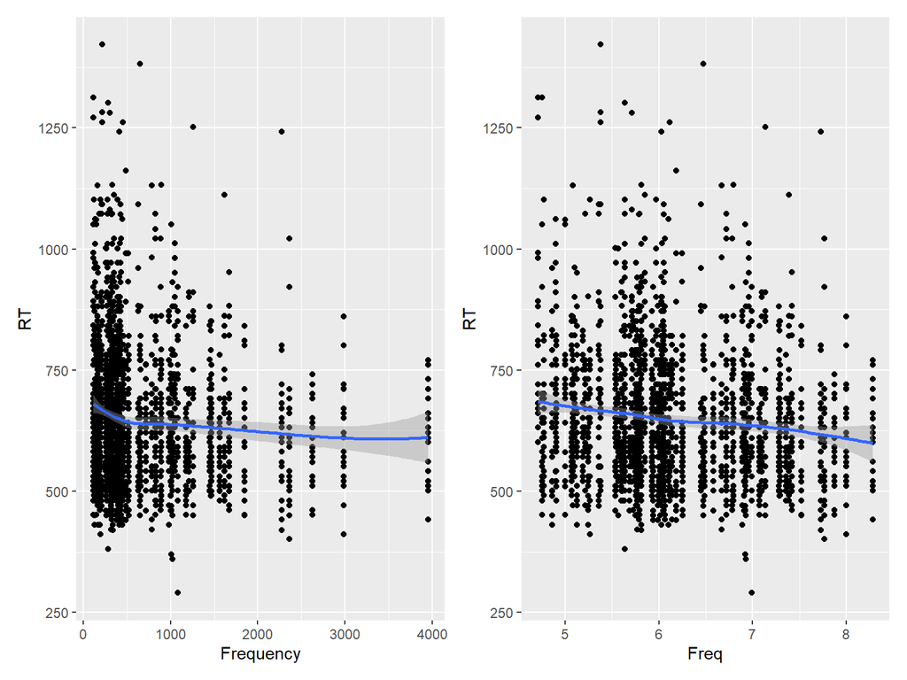

```r
df1$Freq = log(as.numeric(df1$Frequency))

library(ggplot2)
library(patchwork)
g1 = ggplot(df1, aes(x=Frequency, y=RT)) +
  geom_point() +
  geom_smooth(method = "loess", se = TRUE)

g2 = ggplot(df1, aes(x=Freq, y=RT)) +
  geom_point() +
  geom_smooth(method = "loess", se = TRUE)

g1 | g2
```

## In addition, continuous predictors should be centered at zero

- We’ll see later why (when we discuss the interpretability of the intercept) and it’s even better to normalize the values:

```r
df1$logFreq = df1$Freq
df1$Freq_z = scale(as.numeric(df1$Freq))
```

- Let’s see what we did to Freq_z:

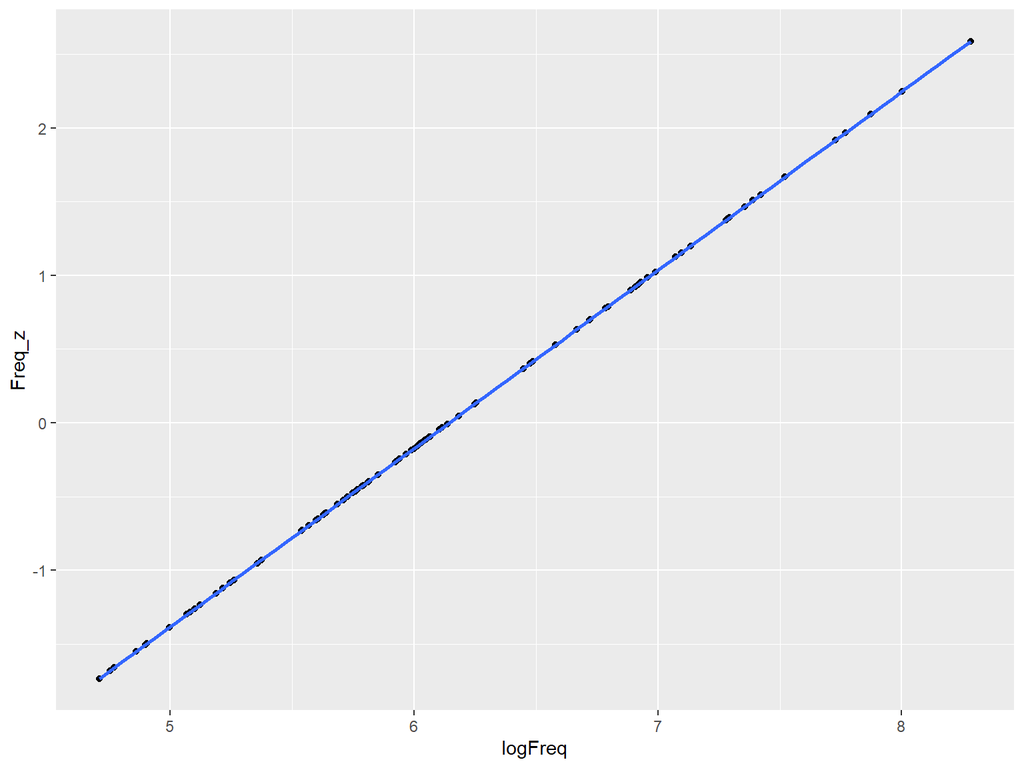

```r
ggplot(df1, aes(x=logFreq, y=Freq_z)) +
  geom_point() +
  geom_smooth(method = "loess", se = TRUE)
```

```r
mean(df1$logFreq)
```

```
## [1] 6.143545
```

```r
exp(mean(df1$logFreq))
```

```
## [1] 465.7017
```

```r
round(mean(df1$Freq_z),5)
```

```
## [1] 0
```

## Let’s also scale the number of senses

```r
df1$NoS = as.numeric(df1$NoS)
df1$NoS_z = scale(df1$NoS)
```

## Let’s check whether the DV (RT) is normally distributed

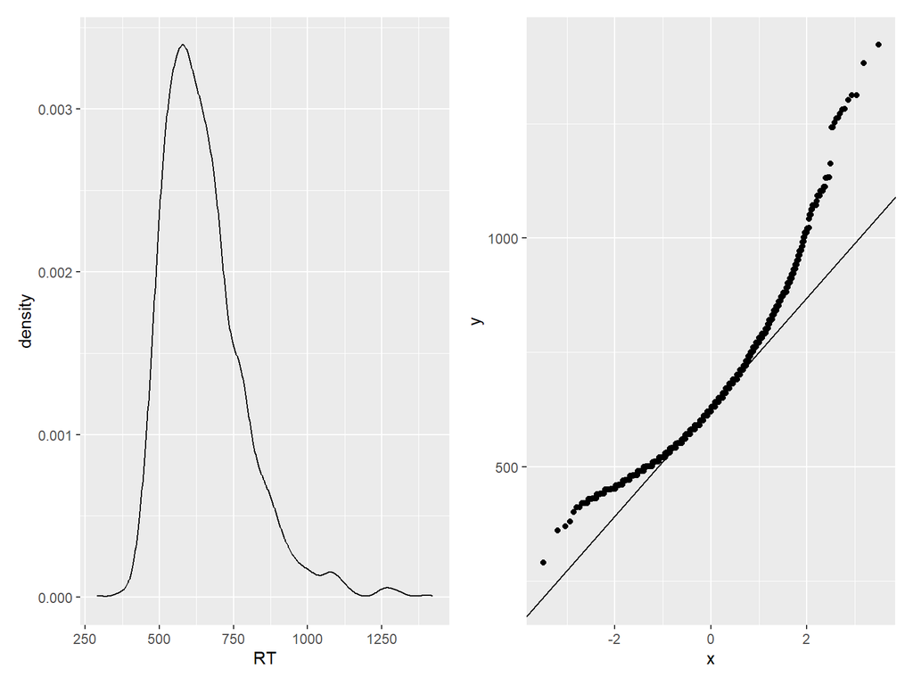

```r
g1 = ggplot(df1, aes(RT)) + geom_density()
g2 = ggplot(df1, aes(sample=RT)) +
  stat_qq() + stat_qq_line()

g1 | g2
```

- Remove extremely short responses

```r
df1 = df1[df1$RT > 300,]
```

## Box-Cox transformation

- Calculates lambda parameter
- Apply the transformation (RT ^ lambda - 1) / lambda
- It boils down to:
  - lambda =1
    - no transformation
  - lambda = 0
    - log transformation
  - lambda = -1
    - inverse transformation
- Make sure all RT>0

```r
df1 = df1[df1$RT > 0, ]
```

- Calculate lambda

```r
library(car)
pt = powerTransform(df1$RT)
summary(pt)
```

```
## bcPower Transformation to Normality
##        Est Power Rounded Pwr Wald Lwr Bnd Wald Upr Bnd
## df1$RT   -1.0018          -1      -1.1832      -0.8203
##
## Likelihood ratio test that transformation parameter is equal to 0
##  (log transformation)
##                            LRT df       pval
## LR test, lambda = (0) 122.9559  1 < 2.22e-16
##
## Likelihood ratio test that no transformation is needed
##                            LRT df       pval
## LR test, lambda = (1) 516.8776  1 < 2.22e-16
```

```r
lambda = pt$lambda
lambda
```

```
##    df1$RT
## -1.001762
```

- Calculate lambda differently

```r
powerTransform(df1$RT)
```

```
## Estimated transformation parameter
##    df1$RT
## -1.001762
```

- Apply the transformation

```r
df1$RT_bc = bcPower(df1$RT, lambda)
```

- Inspect the change

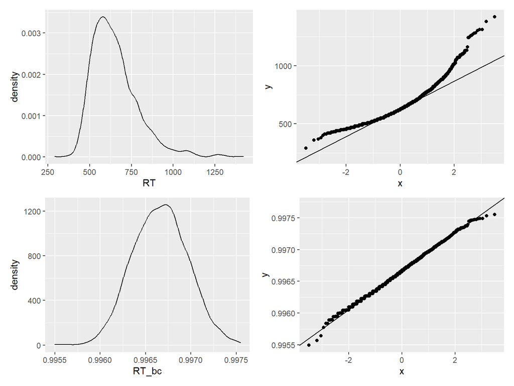

```r
g3 = ggplot(df1, aes(RT_bc)) + geom_density()
g4 = ggplot(df1, aes(sample=RT_bc)) +
  stat_qq() + stat_qq_line()

(g1 | g2) / (g3 | g4)
```

- Heuristics, if lambda is closer to -1 than to 0

```r
df1$RT_inv = -1000/df1$RT
```

- Plot RT, RT_bc and RT_inv

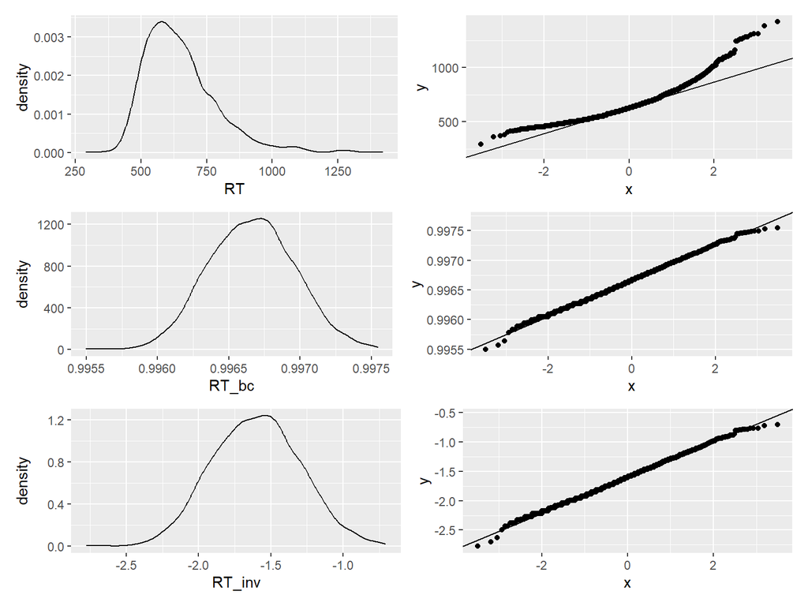

```r
g3 = ggplot(df1, aes(RT_bc)) + geom_density()
g4 = ggplot(df1, aes(sample=RT_bc)) +
  stat_qq() + stat_qq_line()
g5 = ggplot(df1, aes(RT_inv)) + geom_density()
g6 = ggplot(df1, aes(sample=RT_inv)) +
  stat_qq() + stat_qq_line()

(g1 | g2) / (g3 | g4) / (g5 | g6)
```

## Let’s create by-item data

- To compute averages by word, we use the aggregate() function
  - The first argument is the variable we are averaging
  - The second argument is a list defining the groups we’re averaging over
  - The third argument is the action we’re applying

```r
nouns = aggregate(df1$RT, list(df1$Word), mean)
```

- Let’s name the columns

```r
colnames(nouns) = c("Word", "MeanRT")
```

- Now let’s take the columns we need from the large data frame

```r
nouns_by_item = df1[, c("Word", "Length", "Freq_z",
                         "FreCategory", "NoS_z",
                         "PolyLevelCategory")]
```

- Then let’s get rid of all the repeated rows, keeping only one row per word

```r
nouns_by_item = unique (nouns_by_item)
```

- Finally, let’s merge the two new data frames, using the Word column as the key for merging, both in the receiving data frame (nouns_by_item, by.x=) and in the supplying data frame (nouns, by.y=)
  - (This can also be done via the join function — look it up and try to achieve the same thing using one of that function’s variants!)

```r
nouns_by_item = merge(nouns_by_item, nouns, by.x = "Word", by.y = "Word")
```

## Now we have a data frame with average reaction times for words

```r
head(nouns_by_item)
```

```
##     Word Length     Freq_z FreCategory      NoS_z PolyLevelCategory   MeanRT
## 1  [APAT      5 -0.5239181       LowFr -1.5635806          lowPolys 789.6000
## 2  [KOLA      5  0.7766415        HiFr  0.7642896         highPolys 624.7917
## 3 ^E@NJA      6 -0.1423498        HiFr -1.5635806          lowPolys 723.4583
## 4  APRIL      5 -0.0334504        HiFr -1.5635806          lowPolys 635.7500
## 5  BA[TA      5 -0.6504768       LowFr -1.1756022          lowPolys 641.3750
## 6  BLAGO      5 -1.5528573       LowFr  0.7642896         highPolys 625.4583
```

## Let’s create by-participant data

- To compute averages by participant, we use the aggregate() function
  - The first argument is the variable we are averaging
  - The second argument is a list defining the groups we’re averaging over
  - The third argument is the action we’re applying

```r
participants = aggregate(df1$RT,
                         list(df1$Participant, df1$PolyLevelCategory), mean)
```

- Let’s name the columns

```r
colnames(participants) = c("Participant", "PolyLevelCategory", "MeanRT")
```

- Now let’s take the columns we need from the large data frame

```r
nouns_by_participant = df1[, c("Participant", "PolyLevelCategory", "PartSpeed")]
```

- Then let’s get rid of all the repeated rows, keeping only one row per participant

```r
nouns_by_participant = unique (nouns_by_participant)
```

- Finally, let’s merge the two new data frames, using the Participant column as the key for merging

```r
nouns_by_participant = merge(nouns_by_participant, participants,
                             by = c("Participant", "PolyLevelCategory"))
```

```r
head(nouns_by_participant)
```

```
##   Participant PolyLevelCategory PartSpeed   MeanRT
## 1          s1         highPolys  672.2514 565.6207
## 2          s1          lowPolys  672.2514 586.1667
## 3          s1       mediumPolys  672.2514 584.5000
## 4         s10         highPolys  852.1751 772.4828
## 5         s10          lowPolys  852.1751 792.6000
## 6         s10       mediumPolys  852.1751 729.3667
```